# Rolling Sales for Staten Island

Crystal Todd

October 18, 2016

## Results

We will show our process through the analysis to justify the steps taken based on the data’s behaviour.

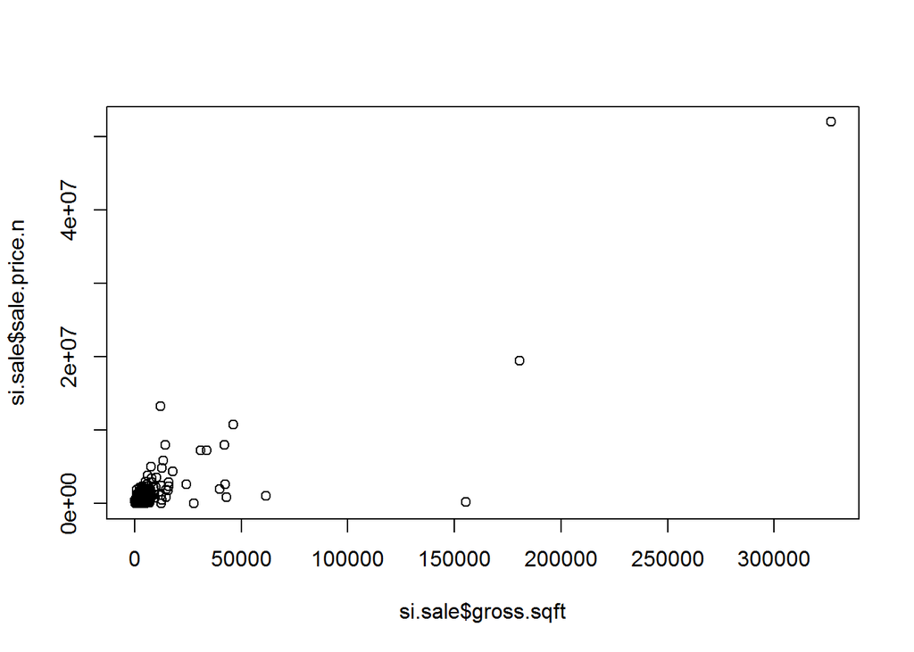

This plot is difficult to see more of the data since the points between 0 and 50,000 are extremely overlapping.

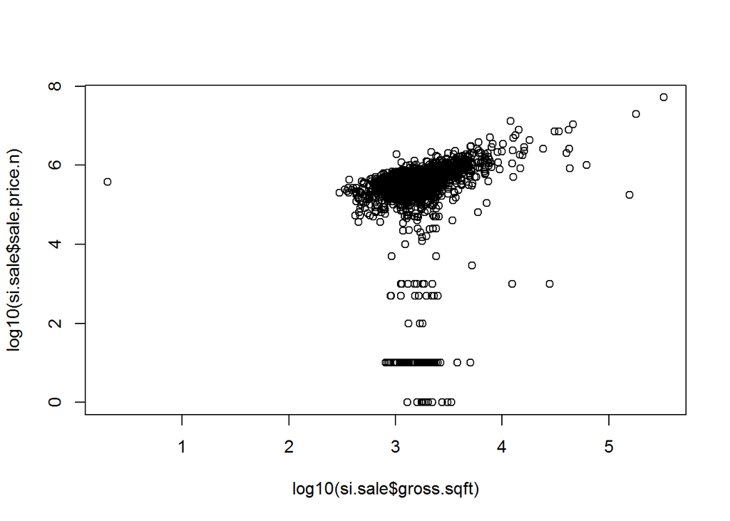

Taking the logarithm of both the gross square feet of the house and the sale price allows for better analysis. Most of the data appears to follow the upward trend of the larger the square feet, the bigger the selling price for the house was. Now, we shall look at the 1-, 2-, and 3- family homes.

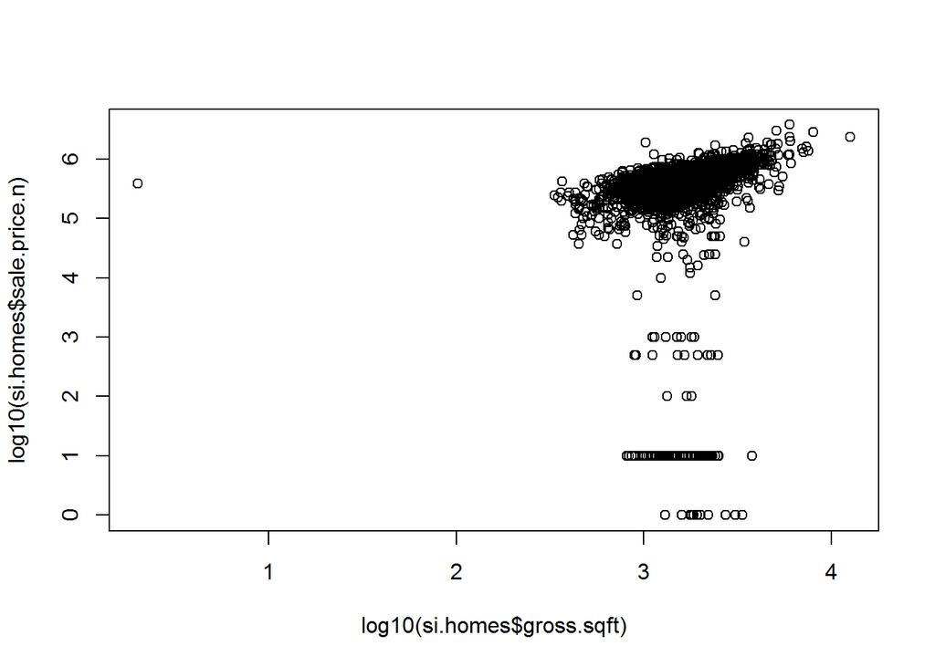

```
##     borough                     neighborhood
##  Min.   :5   PORT RICHMOND            : 15
##  1st Qu.:5   GREAT KILLS              : 11
##  Median :5   WEST NEW BRIGHTON        : 10
##  Mean   :5   MIDLAND BEACH            :  9
##  3rd Qu.:5   ELTINGVILLE              :  8
##  Max.   :5   NEW DORP-BEACH           :  8
##              (Other)                  :115
##                                  building.class.category
##  01  ONE FAMILY DWELLINGS                    :119
##  02  TWO FAMILY DWELLINGS                    : 55
##  03  THREE FAMILY DWELLINGS                  :  2
##  04  TAX CLASS 1 CONDOS                      :  0
##  05  TAX CLASS 1 VACANT LAND                 :  0
##  06  TAX CLASS 1 - OTHER                     :  0
##  (Other)                                     :  0
##  tax.class.at.present     block             lot         ease.ment
##  1      :176          Min.   :  37.0   Min.   :  1.00   Mode:logical
##         :  0          1st Qu.: 965.5   1st Qu.: 20.75   NA's:176
##  1A     :  0          Median :2949.0   Median : 43.50
##  1B     :  0          Mean   :3083.1   Mean   : 74.59
##  1C     :  0          3rd Qu.:5298.0   3rd Qu.: 92.00
##  2      :  0          Max.   :8037.0   Max.   :516.00
##  (Other):  0
##  building.class.at.present                                      address
##  B2     :36                36 INNIS STREET                          :  3
##  A5     :35                23 BACHE STREET                          :  2
##  A2     :33                4314 ARTHUR KILL ROAD                    :  2
##  A1     :32                5 AVENUE B                               :  2
##  B9     :11                51 VAN BUREN STREET                      :  2
##  A6     :10                631 VAN DUZER STREET                     :  2
##  (Other):19                (Other)                                  :163
##      apartment.number    zip.code     residential.units commercial.units
##              :176     Min.   :10301   Min.   :1.000     Min.   :0.000000
##  02B         :  0     1st Qu.:10304   1st Qu.:1.000     1st Qu.:0.000000
##  1           :  0     Median :10306   Median :1.000     Median :0.000000
##  1-Jan       :  0     Mean   :10307   Mean   :1.335     Mean   :0.005682
##  10          :  0     3rd Qu.:10312   3rd Qu.:2.000     3rd Qu.:0.000000
##  100         :  0     Max.   :10314   Max.   :3.000     Max.   :1.000000
##  (Other)     :  0
```

[output cut: 9 more lines]

```
##  Min.   :1                 B2     :36                      10     :75
##  1st Qu.:1                 A5     :35                      1      :11
##  Median :1                 A2     :33                      500    : 9
##  Mean   :1                 A1     :32                      1,000  : 7
##  3rd Qu.:1                 B9     :11                      50,000 : 7
##  Max.   :1                 A6     :10                      25,000 : 4
##                            (Other):19                     (Other) :63
##       sale.date    sale.price.n     gross.sqft     land.sqft
##  1/14/2016 :  4   Min.   :    1   Min.   : 420   Min.   :  640
##  10/27/2015:  4   1st Qu.:   10   1st Qu.:1120   1st Qu.: 2500
##  10/30/2015:  4   Median :  100   Median :1464   Median : 3375
##  6/16/2016 :  4   Mean   :22857   Mean   :1548   Mean   : 3966
##  1/19/2016 :  3   3rd Qu.:50000   3rd Qu.:1956   3rd Qu.: 4809
##  10/29/2015:  3   Max.   :95000   Max.   :3800   Max.   :16530
##  (Other)   :154
```

The summary statement on the data shows that some homes were bought for one dollar. There appears to be some data that are not actual sales. The plot is based on the full data set. Next, we will remove outliers to see if a better restult is produced.

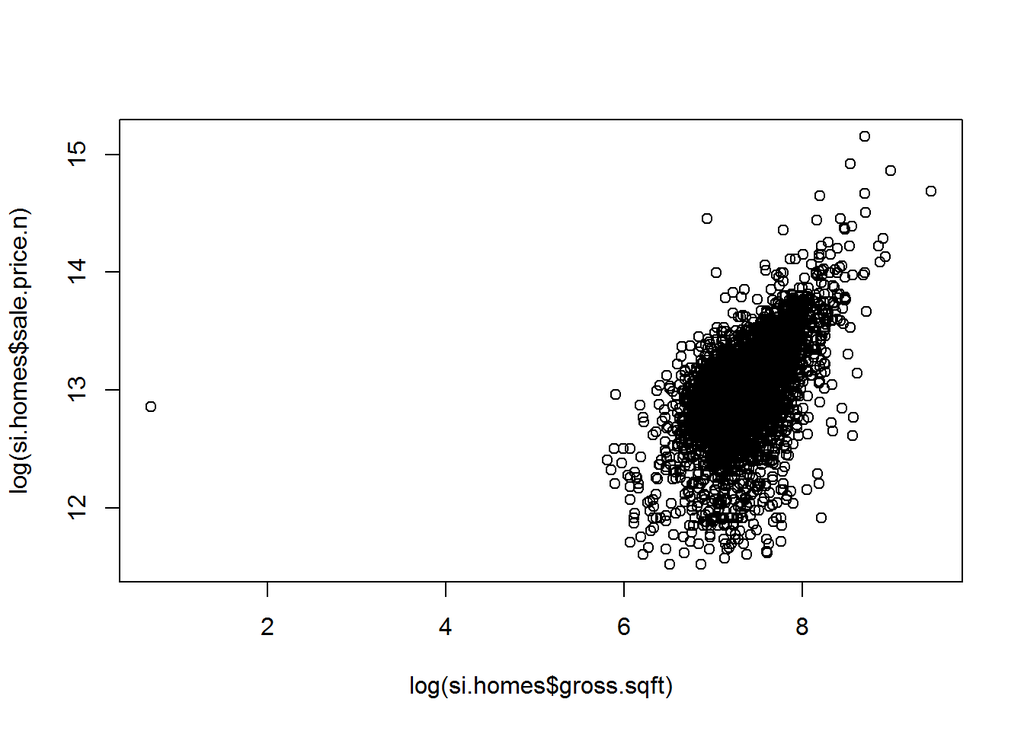

After removing the outliers that did not appear to be actual sales, we can compare the area in each house by the sale price. We can see that the overall trend of the data is that the larger the square footage in a house, the higher the selling price is based on the above graph.

## Conclusion

Visually, we found that the higher sales in homes had larger square feet as well as the lower sales prices had less square footage.